# Validation Date of Lifetime Dog Licenses in Allegheny County

# About Valid date

Data about the validation date contains the year and the time of validation date. We analyze the the trend of lifetime dog licenses over 17 years and the preferred time for people obtaining the lifetime licenses.

# Analysis on Trend over Years from 2003 to 2020

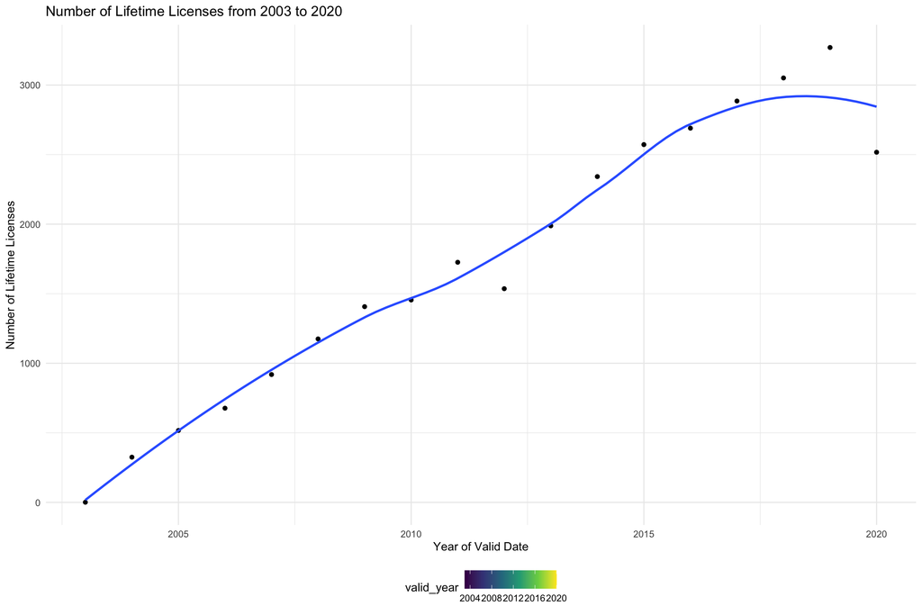

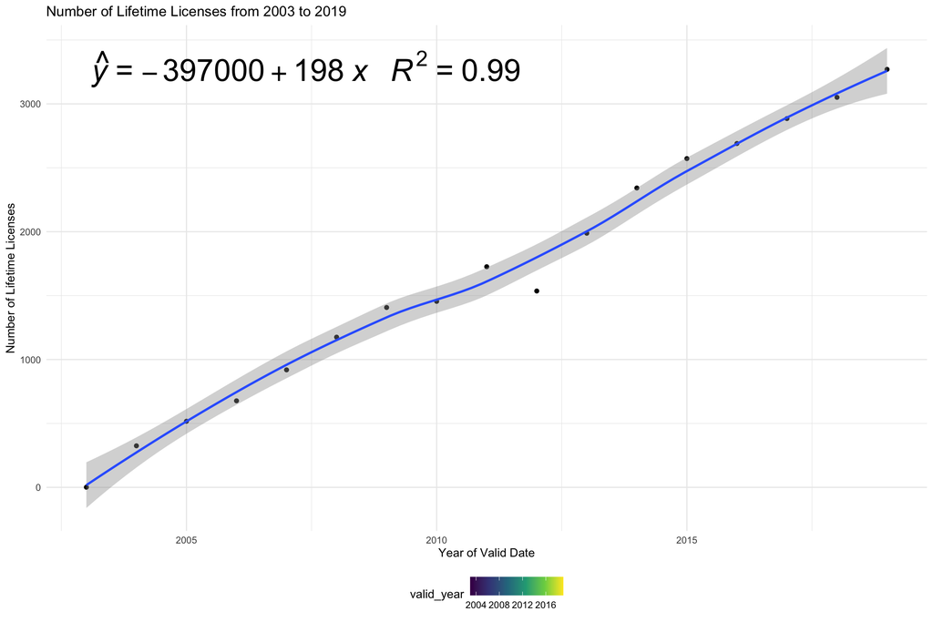

Since the R square is 0.99, we can conclude that the linear equation is robust and we can use it to predict the the number of total dog lifetime licenses in the future without the effects from Covid-19. The 95% confidence interval includes almost all values from 2003 to 2019.

# Analysis on the Prefered Time to Obtain a Dog Lifetime License

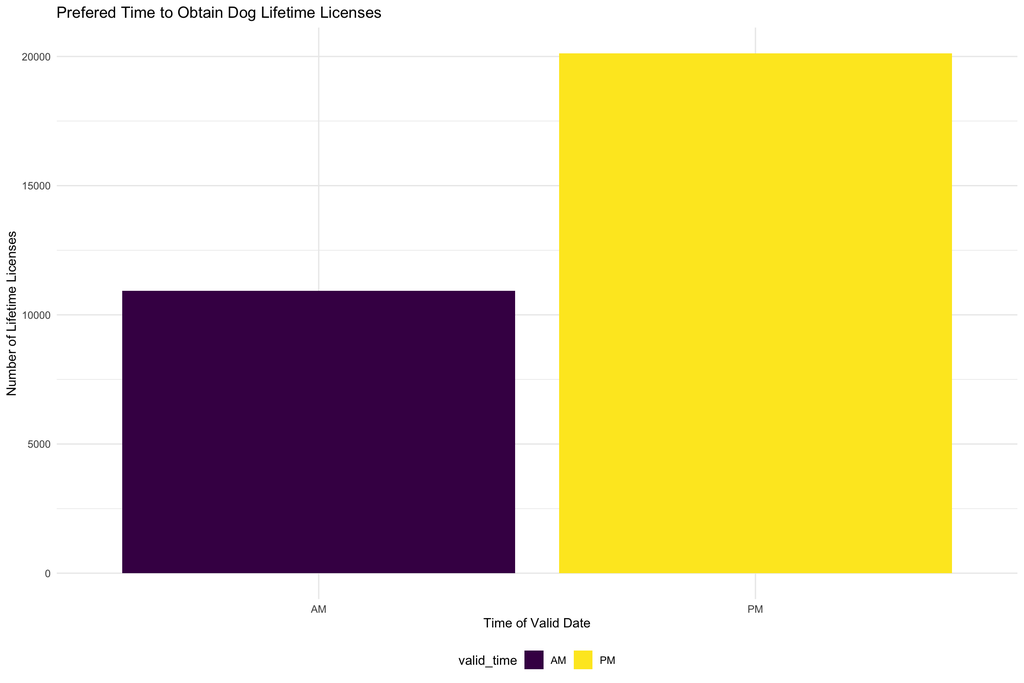

From the bar chart above, people tend to obtain the lifetime licenses on PM rather than AM. The people obtain the lifetime licenses is nearly double the people on AM. .